# Chae_HW_Sample

B. Chae **"K-State Honor Code "On my honor, as a student, I have neither given nor received unauthorized aid on this academic work.**

## 1. My null hypotheses

1. The auto dataset will discuss diffrent kinds of cars and their performance and specs.
2. The fincance dataset will talk about the stock market and make predictions about future market performance and possibly make reccomendations about which stocks to purchase, as well as discuss the performance of certain companies.

```python
# import packages
import pandas as pd
import numpy as np
import wordcloud
import nltk
from nltk.corpus import stopwords
from nltk import FreqDist, word_tokenize
from nltk.stem.porter import PorterStemmer
from nltk.stem import WordNetLemmatizer
from nltk.corpus import stopwords
import re
import csv
import matplotlib as plt
from os import path
from PIL import Image
from wordcloud import WordCloud, STOPWORDS
%matplotlib inline
```

```python
# load data

auto = pd.read_csv('data/auto.csv')
finance = pd.read_csv('data/finance.csv')
```

```python
# text preprocessing for the Auto Dataset
auto_tokens = str(auto)
auto_tokens = auto_tokens.lower()
auto_tokens = re.sub("[^a-zA-Z0-9]", " ", auto_tokens)
auto_tokens = word_tokenize(auto_tokens)
auto_tokens = (word for word in auto_tokens if word not in stopwords.words('english'))
auto_tokens = (word for word in auto_tokens if word.isalpha())
auto_tokens = (word for word in auto_tokens if len(word) >= 3)
wordnet_lemmatizer = WordNetLemmatizer()
auto_tokens = (wordnet_lemmatizer.lemmatize(word) for word in auto_tokens)
```

```python
# Word frequency analysis for Auto dataset

auto_fdist = nltk.FreqDist(auto_tokens)
auto_fdist
```

```
FreqDist({'report': 24, 'korea': 23, 'south': 19, 'video': 16, u'car': 15, u'worker': 15, 'north': 15, 'permalink': 14, 'korean': 14, 'hour': 13, ...})
```

```python
# text preprocessing for the Finance Dataset

fintokens = str(finance)
fintokens = fintokens.lower()
fintokens = re.sub("[^a-zA-Z0-9]", " ", fintokens)
fintokens = word_tokenize(fintokens)
fintokens = (word for word in fintokens if word not in stopwords.words('english'))
fintokens = (word for word in fintokens if word.isalpha())
fintokens = (word for word in fintokens if len(word) >= 3)
fintokens = (wordnet_lemmatizer.lemmatize(word) for word in fintokens)
```

```python
# Word frequency analysis for Finance Dataset

fin_fdist = nltk.FreqDist(fintokens)
fin_fdist
```

```
FreqDist({'ipo': 27, 'stock': 27, 'facebook': 15, 'twitter': 15, 'market': 9, 'new': 8, 'company': 8, 'ceo': 7, 'billion': 7, 'rate': 6, ...})
```

```python
# # Word frequency analysis using bi-grams

auto_bigrams = nltk.bigrams(auto_tokens)

auto_bgr_fdist = nltk.FreqDist(auto_bigrams)
auto_bgr_fdist
```

```
FreqDist({('north', 'korea'): 15, ('report', 'abuse'): 13, ('hour', 'ago'): 13, ('ago', 'report'): 13, ('abuse', 'permalink'): 13, ('south', 'korean'): 12, ('korean', u'worker'): 9, ('fleeing', 'north'): 6, (u'car', 'south'): 6, ('overloaded', u'car'): 6, ...})
```

```python
# # Word frequency analysis using bi-grams


fin_bigrams = nltk.bigrams(fintokens)

fin_bgr_fdist = nltk.FreqDist(fin_bigrams)
fin_bgr_fdist
```

```
FreqDist({('twitter', 'stock'): 6, ('facebook', 'ipo'): 6, ('stock', 'hot'): 5, ('must', 'know'): 5, ('know', 'twitter'): 5, (u'lesson', 'facebook'): 4, ('per', 'share'): 4, ('college', 'football'): 4, ('good', 'deal'): 3, ('economy', 'grew'): 3, ...})
```

## 3. Popular bi-grams from each dataset

```python
#Most Popular Auto Bigrams

auto_bgr_fdist.most_common(15)
```

```
[(('north', 'korea'), 15),
 (('report', 'abuse'), 13),
 (('hour', 'ago'), 13),
 (('ago', 'report'), 13),
 (('abuse', 'permalink'), 13),
 (('south', 'korean'), 12),
 (('korean', u'worker'), 9),
 (('fleeing', 'north'), 6),
 ((u'car', 'south'), 6),
 (('overloaded', u'car'), 6),
 (('south', 'korea'), 6),
 ((u'worker', 'fleeing'), 6),
 (('two', u'country'), 5),
 (('korea', 'south'), 3),
 (('escalate', 'two'), 3)]
```

```python
#Most Popular Finance Bigrams

fin_bgr_fdist.most_common(15)
```

```
[(('twitter', 'stock'), 6),
 (('facebook', 'ipo'), 6),
 (('stock', 'hot'), 5),
 (('must', 'know'), 5),
 (('know', 'twitter'), 5),
 ((u'lesson', 'facebook'), 4),
 (('per', 'share'), 4),
 (('college', 'football'), 4),
 (('good', 'deal'), 3),
 (('economy', 'grew'), 3),
 (('part', 'twitter'), 3),
 (('hot', 'good'), 3),
 (('jos', 'bank'), 3),
 (('fourth', 'quarter'), 3),
 (('super', 'bowl'), 3)]
```

## 4. A separate word cloud for each data using a mask image (auto vs. finance). The size of word cloud should be large enough for comparison (figsize=(16,16)). Make sure to remove stopwords.

```
(-0.5, 308.5, 162.5, -0.5)
```

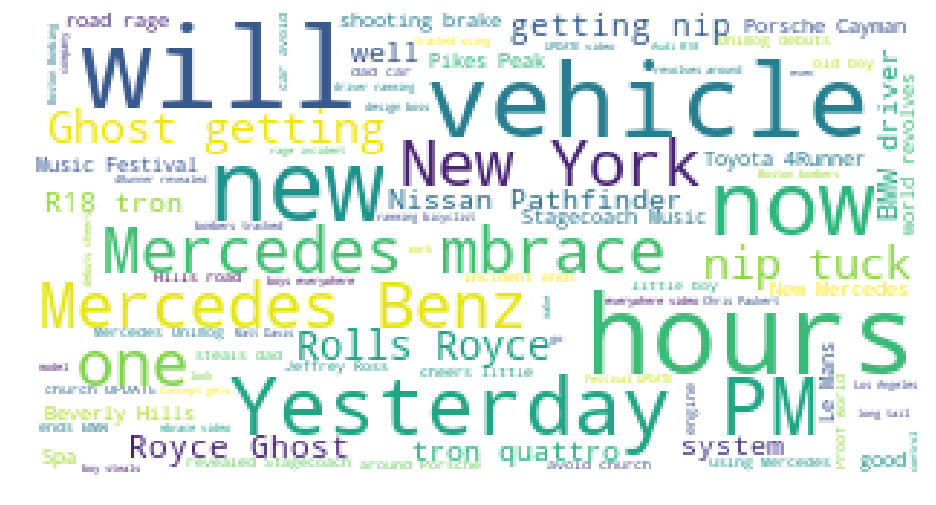

```python
# Auto word cloud

from os import path
from PIL import Image
import numpy as np
import matplotlib.pyplot as plt
from wordcloud import WordCloud, STOPWORDS, ImageColorGenerator

d = path.dirname("data/examples/")
text = open(path.join(d, 'auto.txt')).read()
auto_coloring = np.array(Image.open(path.join(d, "car.png")))

stopwords = set(STOPWORDS)
stopwords.add("report")
stopwords.add("ago")
stopwords.add("hour")
stopwords.add("permalink")
stopwords.add("year")
stopwords.add("abuse")


wc = WordCloud(background_color="white", max_words=2000, mask=auto_coloring,
               stopwords=stopwords, max_font_size=40, random_state=42)

wc.generate(text)

image_colors = ImageColorGenerator(auto_coloring)

plt.figure(figsize=(16,16))
plt.imshow(wc)
plt.axis("off")
```

```
(-0.5, 245.5, 204.5, -0.5)
```

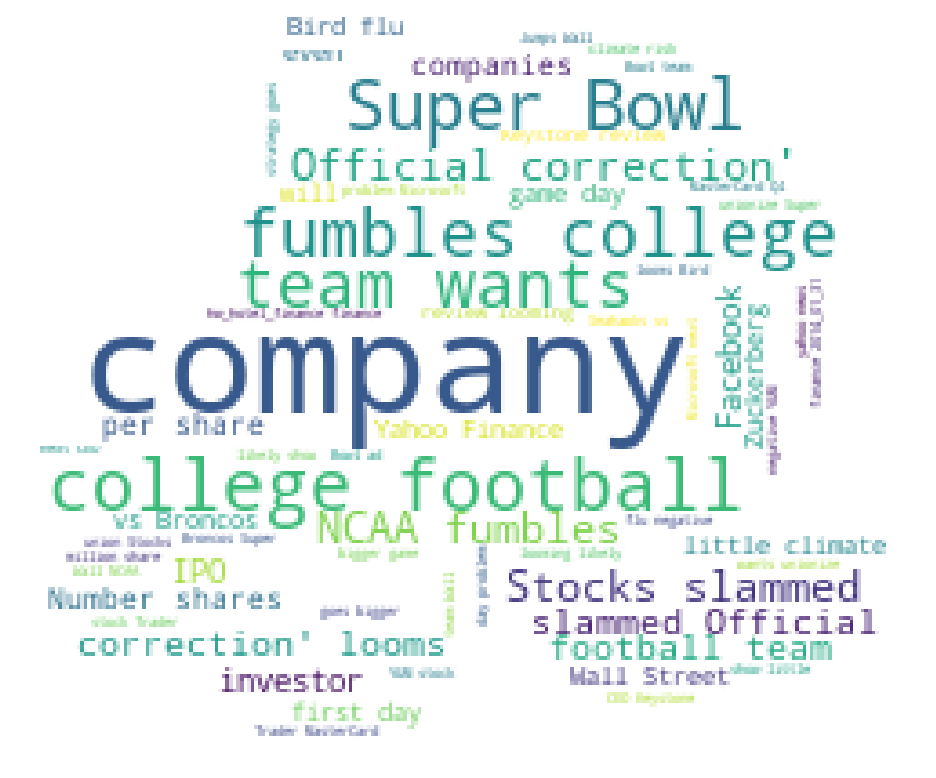

```python
# Finance word cloud


from os import path
from PIL import Image
import numpy as np
import matplotlib.pyplot as plt
from wordcloud import WordCloud, STOPWORDS, ImageColorGenerator

d = path.dirname("data/examples/")
text = open(path.join(d, 'finance.csv')).read()
auto_coloring = np.array(Image.open(path.join(d, "finance.JPG")))

stopwords = set(STOPWORDS)

wc = WordCloud(background_color="white", max_words=2000, mask=auto_coloring,
               stopwords=stopwords, max_font_size=40, random_state=42)

wc.generate(text)

image_colors = ImageColorGenerator(auto_coloring)

plt.figure(figsize=(16,16))
plt.imshow(wc)
plt.axis("off")
```

## 5. The results of testing your hypotheses

1. The auto article talked about different kinds of cars and what kinds of cars were popular. This was in line with what I had expected the article to mention.
1. The finance article talked about stocks but it also talked about college football which was not something that I predicted the article would talk about

## 6. Explain the following concepts and methods and why they are needed (You must use YOUR OWN WORDS to answer the following terms. Copying texts from the lecture note/the Internet is strictly prohibited)

- a. Text (pre)processing
- b. Tokenization
- c. Stopwords
- d. Lowercase
- e. Short words
- f. Stemming

##### A: Text preprocessing is the technique of cleaning up and removing non alphanumeric characters from our text and turning the text into what we would call plain english

##### B: Tokenization is the process of splitting up each word in our text document into individual words, called tokens, so that we can analyze them.

##### C: Stopwords are words that appear frequently in language but do not really provide any meaningful information in terms of producing actionable information. Removing stopwords is necessary so that we can further refine our text document to just have words that we belive are important to our analysis.

##### D: Lowercasing words is the process of converting all of the words in our document to lowercase. This is an important step in NLP because python views uppercase and lowercase words, strings, and variables as different things, and we dont want to have cases of words appearing more than once because we didnt normalize our text by lowercasing words.

##### E: Short words are like the name implies, words that are short. Short words generally do not provide us much meaning, because they are words like and, but, or, if, so, etc. Since these words dont provide us any insights into what our text document is saying, we want to throw them out in order to better organize and clean our data for analysis.

##### F: Stemming is the process of removing the prefixes and suffixes of words to only get the root word for analysis. This is important again for many of the same reasons that lowercasing is. Python will interpret words like "map" and "mapping" and "mapped" to all be 3 different words, and this can cause an overrepresentation of a certain word or words in our analysis, making our results useless.